# Abstract

## Introduction

### Liver cirrhosis is a progressive and irreversible condition characterized by extensive fibrosis and the formation of regenerative nodules, which ultimately impair liver function. It represents the final stage of chronic liver diseases (CLDs) and is a leading cause of morbidity and mortality worldwide (Schuppan & Afdhal, 2008). The disease is a consequence of sustained liver injury due to various etiologies, including chronic hepatitis B and C infections, excessive alcohol consumption, and metabolic dysfunction–associated steatotic liver disease (MASLD) (Tsochatzis et al., 2014). Liver cirrhosis is a major global health concern, with approximately 2 million deaths annually attributed to cirrhosis-related complications such as liver failure, portal hypertension, and hepatocellular carcinoma (Asrani et al., 2019).

### The pathophysiology of cirrhosis is driven by a persistent cycle of liver injury, inflammation, and wound-healing responses, leading to excessive deposition of extracellular matrix (ECM) proteins, primarily collagen (Bataller & Brenner, 2005). Hepatic stellate cells (HSCs) play a central role in fibrosis progression, as they transform into myofibroblast-like cells that secrete ECM components in response to chronic injury (Hernandez-Gea & Friedman, 2011). Over time, fibrotic tissue disrupts the normal hepatic architecture, leading to increased intrahepatic resistance and portal hypertension, a hallmark of cirrhosis.

### Clinically, cirrhosis progresses through compensated and decompensated stages. The compensated stage is often asymptomatic, with normal liver function despite fibrotic damage. As the disease advances, patients develop complications such as ascites, hepatic encephalopathy, and variceal bleeding, indicating decompensation and an increased risk of liver-related mortality (D’Amico et al., 2018). Diagnosis of cirrhosis typically involves a combination of clinical assessment, biochemical markers, imaging techniques (e.g., elastography), and liver biopsy when necessary (European Association for the Study of the Liver [EASL], 2015).

### Liver cirrhosis is a chronic and progressive liver disease that leads to liver failure if not detected and managed in its early stages. Traditional diagnostic approaches, such as biopsies and blood tests, often have limitations in accuracy, invasiveness, and cost-effectiveness. With the advancement of machine learning (ML), automated models can assist in classifying liver cirrhosis stages more accurately and efficiently. However, selecting the best ML model remains a challenge due to differences in model performance, feature importance, and computational efficiency. This study evaluates multiple ML models to determine the most effective approach for Liver Cirrhosis Stage Prediction using a dataset containing key clinical features such as Bilirubin, Albumin, Platelets, and Prothrombin levels, as well as patient demographics and medical conditions.The dataset used in this study contains various medical and demographic attributes that serve as potential predictors for liver cirrhosis stages. These attributes include patient demographics (age, sex), clinical symptoms (ascites, hepatomegaly, edema, and spider angiomas), liver function biomarkers (bilirubin, albumin, SGOT, and prothrombin), metabolic markers (cholesterol, triglycerides, alkaline phosphatase, and copper), and hematological factors (platelet count) (Pimpin et al., 2018).

#### N_Days – Represents the number of days the patient has been under observation in the study. This can be useful for understanding disease progression over time.

#### Status – Indicates the patient’s current condition, which can be:

```
                *Alive (patient is still living)
                 *Dead (patient has passed away)
                 *Transplanted (patient has undergone a liver transplant)
```

#### Drug – Specifies the type of treatment the patient has received. This can help analyze whether certain treatments affect disease progression.

#### Age – The patient’s age at the time of observation, which may be a risk factor for disease severity.

#### Sex – The biological sex of the patient (Male/Female), which can influence disease presentation and progression.

#### Ascites – A binary indicator (Yes/No) of fluid accumulation in the abdominal cavity, a common symptom of liver cirrhosis.

#### Hepatomegaly – A binary indicator (Yes/No) of an enlarged liver, often associated with liver disease.

#### Spiders – A binary indicator (Yes/No) for the presence of spider angiomas, which are small, dilated blood vessels seen in liver disease patients.

#### Edema – A categorical variable indicating the presence of swelling due to fluid retention. Possible values:

```
            * No edema
            * Edema not responding to diuretics
            * Edema responding to diuretics
```

#### Bilirubin – A liver function biomarker indicating the level of bilirubin in the blood. High bilirubin levels suggest impaired liver function.

#### Cholesterol – Measures the cholesterol level in the blood. Liver dysfunction can cause abnormal cholesterol metabolism.

#### Albumin – A protein produced by the liver, essential for maintaining blood volume and transporting substances. Low levels indicate poor liver function.

#### Copper – Measures copper levels in the blood. The liver plays a key role in copper metabolism, and abnormal levels may indicate liver disease.

#### Alk_Phos (Alkaline Phosphatase) – An enzyme that indicates liver function. Elevated levels may signal bile duct obstruction or liver damage.

#### SGOT (Serum Glutamic Oxaloacetic Transaminase) – Also known as AST (Aspartate Aminotransferase), this enzyme is released when liver cells are damaged.

#### Tryglicerides – The level of triglycerides (a type of fat) in the blood, which may be affected by liver disease.

#### Platelets – The number of platelets in the blood, important for clotting. Low platelet count is common in liver cirrhosis.

#### Prothrombin – The time taken for blood to clot. A prolonged prothrombin time indicates impaired liver function and a higher risk of bleeding.

#### Stage – The target variable representing different stages of liver cirrhosis. The number of stages may vary depending on the classification system used (e.g., mild, moderate, severe).

##### This dataset includes a mix of categorical and numerical variables, all of which are crucial for predicting liver cirrhosis stages using machine learning models

## Methodology

#### The following Python libraries were utilized for various stages of data processing, analysis, and model building

#### Pandas: A powerful Python library used for data manipulation and analysis, particularly for handling tabular data. It was used for loading, cleaning, and transforming the dataset.NumPy: A library for numerical operations and handling arrays. It was used for mathematical functions and numerical computations on data.Matplotlib: A plotting library used for creating static, interactive, and animated visualizations, including histograms, scatter plots, and box plots, to explore and visualize data.Seaborn: A statistical data visualization library built on top of Matplotlib, used for creating advanced visualizations such as heatmaps and pair plots to analyze relationships in data.Scikit-learn: A machine learning library used for model building and evaluation. It provides tools for training and evaluating classifiers, including Decision Trees, Logistic Regression, SVM, Random Forest, and K-Nearest Neighbors (KNN).Plotly: A graphing library used for creating interactive visualizations. It was used for generating subplots to represent complex data in an interactive format.itertools: A Python module used for creating iterators that efficiently loop through data. It was utilized to generate combinations and permutations during the analysis.Warnings: A module used to filter out unnecessary warnings during the execution of the code, ensuring cleaner output and focus during the analysis.Scikit-learn: A comprehensive machine learning library that provides tools for data preprocessing, model building, and evaluation. It was used for training various classifiers such as Decision Tree, Logistic Regression, Support Vector Machine (SVM), Random Forest, and K-Nearest Neighbors (KNN). It also provided functions for model evaluation through metrics like confusion matrix, ROC curve, precision-recall curve, and AUC.

```python
import pandas as pd
import numpy as np
import matplotlib.pyplot as plt
import seaborn as sns
import itertools
import warnings
warnings.filterwarnings("ignore")
```

### Data Collection

The dataset for this project was collected from two reliable sources:

1. **Cirrhosis Patient Survival Prediction Dataset** from the UCI Machine Learning Repository, which provides data on patients diagnosed with cirrhosis. This dataset contains information related to the survival prediction of these patients based on various medical features. The dataset can be accessed [here](https://archive.ics.uci.edu/dataset/878/cirrhosis+patient+survival+prediction+dataset-1).
2. **Liver Cirrhosis Stage Classification Dataset** from Kaggle, which offers data about liver cirrhosis stages, containing records related to different stages of cirrhosis in patients. This dataset is useful for predicting the stage of cirrhosis based on patient attributes. The dataset can be accessed [here](https://www.kaggle.com/datasets/aadarshvelu/liver-cirrhosis-stage-classification).

These datasets provide valuable features for analyzing liver cirrhosis and predicting patient outcomes, which are pivotal for the development of predictive models.

```python
df = pd.read_csv(r"C:\Users\manoj\Downloads\Liver_Cirrhosis\liver_cirrhosis.csv")
```

```python
df.head()
```

|  | N_Days | Status | Drug | Age | Sex | Ascites | Hepatomegaly | Spiders | Edema | Bilirubin | Cholesterol | Albumin | Copper | Alk_Phos | SGOT | Tryglicerides | Platelets | Prothrombin | Stage |
| --- | --- | --- | --- | --- | --- | --- | --- | --- | --- | --- | --- | --- | --- | --- | --- | --- | --- | --- | --- |
| 0 | 2221 | C | Placebo | 18499 | F | N | Y | N | N | 0.5 | 149.0 | 4.04 | 227.0 | 598.0 | 52.70 | 57.0 | 256.0 | 9.9 | 1 |
| 1 | 1230 | C | Placebo | 19724 | M | Y | N | Y | N | 0.5 | 219.0 | 3.93 | 22.0 | 663.0 | 45.00 | 75.0 | 220.0 | 10.8 | 2 |
| 2 | 4184 | C | Placebo | 11839 | F | N | N | N | N | 0.5 | 320.0 | 3.54 | 51.0 | 1243.0 | 122.45 | 80.0 | 225.0 | 10.0 | 2 |
| 3 | 2090 | D | Placebo | 16467 | F | N | N | N | N | 0.7 | 255.0 | 3.74 | 23.0 | 1024.0 | 77.50 | 58.0 | 151.0 | 10.2 | 2 |
| 4 | 2105 | D | Placebo | 21699 | F | N | Y | N | N | 1.9 | 486.0 | 3.54 | 74.0 | 1052.0 | 108.50 | 109.0 | 151.0 | 11.5 | 1 |

```python
df.tail()
```

|  | N_Days | Status | Drug | Age | Sex | Ascites | Hepatomegaly | Spiders | Edema | Bilirubin | Cholesterol | Albumin | Copper | Alk_Phos | SGOT | Tryglicerides | Platelets | Prothrombin | Stage |
| --- | --- | --- | --- | --- | --- | --- | --- | --- | --- | --- | --- | --- | --- | --- | --- | --- | --- | --- | --- |
| 24995 | 3584 | D | D-penicillamine | 23612 | F | N | N | N | N | 0.8 | 231.000000 | 3.87 | 173.0 | 9009.8 | 127.71 | 96.000000 | 295.0 | 11.0 | 2 |
| 24996 | 3584 | D | D-penicillamine | 23612 | F | N | N | N | N | 0.8 | 231.000000 | 3.87 | 173.0 | 9009.8 | 127.71 | 96.000000 | 295.0 | 11.0 | 2 |
| 24997 | 971 | D | D-penicillamine | 16736 | F | N | Y | Y | Y | 5.1 | 369.510563 | 3.23 | 18.0 | 790.0 | 179.80 | 124.702128 | 104.0 | 13.0 | 3 |
| 24998 | 3707 | C | D-penicillamine | 16990 | F | N | Y | N | N | 0.8 | 315.000000 | 4.24 | 13.0 | 1637.0 | 170.50 | 70.000000 | 426.0 | 10.9 | 2 |
| 24999 | 3707 | C | D-penicillamine | 16990 | F | N | Y | N | N | 0.8 | 315.000000 | 4.24 | 13.0 | 1637.0 | 170.50 | 70.000000 | 426.0 | 10.9 | 2 |

```python
df.info()
```

```
<class 'pandas.core.frame.DataFrame'>
RangeIndex: 25000 entries, 0 to 24999
Data columns (total 19 columns):
 #   Column         Non-Null Count  Dtype
---  ------         --------------  -----
 0   N_Days         25000 non-null  int64
 1   Status         25000 non-null  object
 2   Drug           25000 non-null  object
 3   Age            25000 non-null  int64
 4   Sex            25000 non-null  object
 5   Ascites        25000 non-null  object
 6   Hepatomegaly   25000 non-null  object
 7   Spiders        25000 non-null  object
 8   Edema          25000 non-null  object
 9   Bilirubin      25000 non-null  float64
 10  Cholesterol    25000 non-null  float64
 11  Albumin        25000 non-null  float64
 12  Copper         25000 non-null  float64
 13  Alk_Phos       25000 non-null  float64
 14  SGOT           25000 non-null  float64
 15  Tryglicerides  25000 non-null  float64
 16  Platelets      25000 non-null  float64
 17  Prothrombin    25000 non-null  float64
 18  Stage          25000 non-null  int64
dtypes: float64(9), int64(3), object(7)
memory usage: 3.6+ MB
```

```python
df.columns
```

```
Index(['N_Days', 'Status', 'Drug', 'Age', 'Sex', 'Ascites', 'Hepatomegaly',
       'Spiders', 'Edema', 'Bilirubin', 'Cholesterol', 'Albumin', 'Copper',
       'Alk_Phos', 'SGOT', 'Tryglicerides', 'Platelets', 'Prothrombin',
       'Stage'],
      dtype='object')
```

## DATA CLEANING

```python
df.shape
```

```
(25000, 19)
```

```python
df.shape[0]
```

```
25000
```

```python
df.shape[1]
```

```
19
```

### coumns are 19

```python
df.isnull()
```

|  | N_Days | Status | Drug | Age | Sex | Ascites | Hepatomegaly | Spiders | Edema | Bilirubin | Cholesterol | Albumin | Copper | Alk_Phos | SGOT | Tryglicerides | Platelets | Prothrombin | Stage |
| --- | --- | --- | --- | --- | --- | --- | --- | --- | --- | --- | --- | --- | --- | --- | --- | --- | --- | --- | --- |
| 0 | False | False | False | False | False | False | False | False | False | False | False | False | False | False | False | False | False | False | False |
| 1 | False | False | False | False | False | False | False | False | False | False | False | False | False | False | False | False | False | False | False |
| 2 | False | False | False | False | False | False | False | False | False | False | False | False | False | False | False | False | False | False | False |
| 3 | False | False | False | False | False | False | False | False | False | False | False | False | False | False | False | False | False | False | False |
| 4 | False | False | False | False | False | False | False | False | False | False | False | False | False | False | False | False | False | False | False |
| ... | ... | ... | ... | ... | ... | ... | ... | ... | ... | ... | ... | ... | ... | ... | ... | ... | ... | ... | ... |
| 24995 | False | False | False | False | False | False | False | False | False | False | False | False | False | False | False | False | False | False | False |
| 24996 | False | False | False | False | False | False | False | False | False | False | False | False | False | False | False | False | False | False | False |
| 24997 | False | False | False | False | False | False | False | False | False | False | False | False | False | False | False | False | False | False | False |
| 24998 | False | False | False | False | False | False | False | False | False | False | False | False | False | False | False | False | False | False | False |
| 24999 | False | False | False | False | False | False | False | False | False | False | False | False | False | False | False | False | False | False | False |

25000 rows × 19 columns

```python
df.isnull().sum()
```

```
N_Days           0
Status           0
Drug             0
Age              0
Sex              0
Ascites          0
Hepatomegaly     0
Spiders          0
Edema            0
Bilirubin        0
Cholesterol      0
Albumin          0
Copper           0
Alk_Phos         0
SGOT             0
Tryglicerides    0
Platelets        0
Prothrombin      0
Stage            0
dtype: int64
```

```python
df = df.dropna()
```

```python
df.describe()
```

|  | N_Days | Age | Bilirubin | Cholesterol | Albumin | Copper | Alk_Phos | SGOT | Tryglicerides | Platelets | Prothrombin | Stage |
| --- | --- | --- | --- | --- | --- | --- | --- | --- | --- | --- | --- | --- |
| count | 25000.000000 | 25000.000000 | 25000.000000 | 25000.000000 | 25000.000000 | 25000.000000 | 25000.000000 | 25000.000000 | 25000.000000 | 25000.000000 | 25000.000000 | 25000.00000 |
| mean | 1887.117040 | 18495.877080 | 3.402644 | 372.331471 | 3.486578 | 100.184663 | 1995.675597 | 123.166345 | 123.822548 | 256.007337 | 10.734549 | 2.00116 |
| std | 1091.690918 | 3737.596616 | 4.707491 | 193.668452 | 0.380488 | 73.184840 | 1798.885660 | 47.747616 | 52.786350 | 98.679006 | 0.904436 | 0.81387 |
| min | 41.000000 | 9598.000000 | 0.300000 | 120.000000 | 1.960000 | 4.000000 | 289.000000 | 26.350000 | 33.000000 | 62.000000 | 9.000000 | 1.00000 |
| 25% | 1080.000000 | 15694.000000 | 0.800000 | 275.000000 | 3.290000 | 52.000000 | 1032.000000 | 92.000000 | 92.000000 | 189.000000 | 10.000000 | 1.00000 |
| 50% | 1680.000000 | 18499.000000 | 1.300000 | 369.510563 | 3.510000 | 97.648387 | 1828.000000 | 122.556346 | 124.702128 | 251.000000 | 10.600000 | 2.00000 |
| 75% | 2576.000000 | 20955.000000 | 3.400000 | 369.510563 | 3.750000 | 107.000000 | 1982.655769 | 134.850000 | 127.000000 | 311.000000 | 11.100000 | 3.00000 |
| max | 4795.000000 | 28650.000000 | 28.000000 | 1775.000000 | 4.640000 | 588.000000 | 13862.400000 | 457.250000 | 598.000000 | 721.000000 | 18.000000 | 3.00000 |

```python
df.columns
```

```
Index(['N_Days', 'Status', 'Drug', 'Age', 'Sex', 'Ascites', 'Hepatomegaly',
       'Spiders', 'Edema', 'Bilirubin', 'Cholesterol', 'Albumin', 'Copper',
       'Alk_Phos', 'SGOT', 'Tryglicerides', 'Platelets', 'Prothrombin',
       'Stage'],
      dtype='object')
```

```python
df.dtypes
```

```
N_Days             int64
Status            object
Drug              object
Age                int64
Sex               object
Ascites           object
Hepatomegaly      object
Spiders           object
Edema             object
Bilirubin        float64
Cholesterol      float64
Albumin          float64
Copper           float64
Alk_Phos         float64
SGOT             float64
Tryglicerides    float64
Platelets        float64
Prothrombin      float64
Stage              int64
dtype: object
```

### EXPLORATORY DATA ANALYISIS

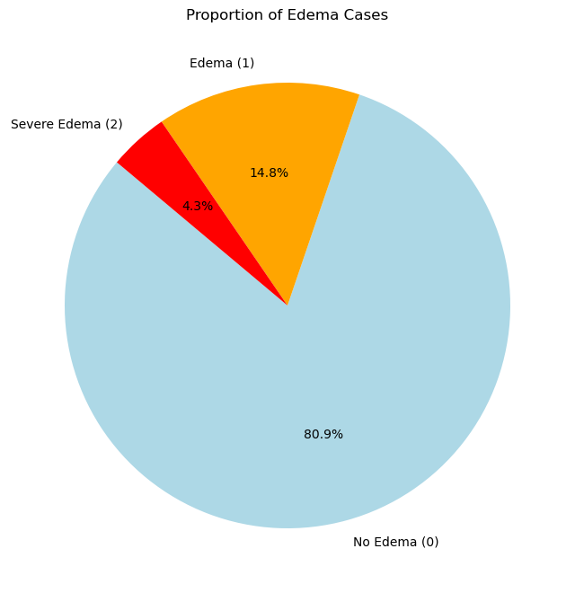

```python
edema_counts = df['Edema'].value_counts()
labels = ['No Edema (0)', 'Edema (1)', 'Severe Edema (2)']
plt.figure(figsize=(8,9))
colors = ['lightblue', 'orange', 'red']
plt.pie(edema_counts, labels=labels, autopct='%1.1f%%', colors=colors, startangle=140)
plt.title("Proportion of Edema Cases")
plt.show()
```

[figure not shown]

```python
plt.figure(figsize=(6, 4))
sns.countplot(x='Sex', data=df, palette="rocket")
plt.xticks(ticks=[0, 1], labels=["Male", "Female"])
plt.title("Distribution of Sex")
plt.xlabel("Sex")
plt.ylabel("Count")
plt.show()
```

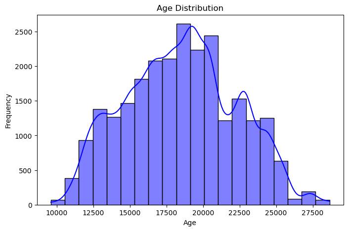

```python
plt.figure(figsize=(8, 5))
sns.histplot(df['Age'], bins=20, kde=True, color="blue")
plt.title("Age Distribution")
plt.xlabel("Age")
plt.ylabel("Frequency")
plt.show()
```

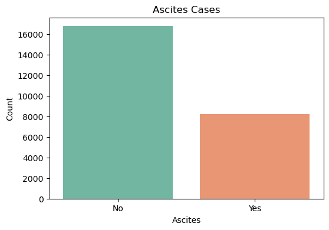

```python
plt.figure(figsize=(6, 4))
sns.countplot(x='Ascites', data=df, palette="Set2")
plt.xticks(ticks=[0, 1], labels=["No", "Yes"])
plt.title("Ascites Cases")
plt.xlabel("Ascites")
plt.ylabel("Count")
plt.show()
```

[figure not shown]

```python
plt.figure(figsize=(6, 4))
sns.countplot(x='Hepatomegaly', data=df, palette="Set1")
plt.xticks(ticks=[0, 1], labels=["No", "Yes"])
plt.title("Hepatomegaly")
plt.xlabel("Hepatomegaly")
plt.ylabel("Count")
plt.show()
```

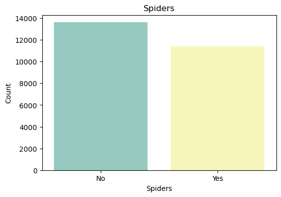

```python
plt.figure(figsize=(6, 4))
sns.countplot(x='Spiders', data=df, palette="Set3")
plt.xticks(ticks=[0, 1], labels=["No", "Yes"])
plt.title("Spiders")
plt.xlabel("Spiders")
plt.ylabel("Count")
plt.show()
```

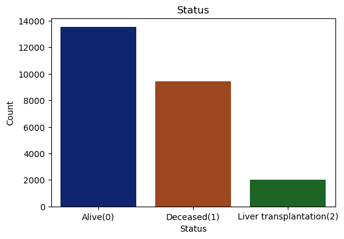

```python
status_counts = df['Status'].value_counts()
plt.figure(figsize=(6, 4))
sns.countplot(x='Status', data=df, palette="dark")
plt.xticks(ticks=[0, 1, 2], labels=["Alive(0)", "Deceased(1)", "Liver transplantation(2)"])
plt.title("Status")
plt.xlabel("Status")
plt.ylabel("Count")
plt.show()
```

[figure not shown]

```python
fig, axes = plt.subplots(1, 2, figsize=(12, 5))
sns.countplot(x='Hepatomegaly', data=df, ax=axes[0], palette="viridis")
axes[0].set_xticks([0, 1])
axes[0].set_xticklabels(["No", "Yes"])
axes[0].set_title("Hepatomegaly Cases")

sns.countplot(x='Spiders', data=df, ax=axes[1], palette="magma")
axes[1].set_xticks([0, 1])
axes[1].set_xticklabels(["No", "Yes"])
axes[1].set_title("Spider Angiomas Cases")
```

[figure not shown]

```python
fig, axes = plt.subplots(1, 2, figsize=(12, 5))
sns.countplot(x='Edema', data=df, ax=axes[0], palette="icefire")
axes[0].set_xticks([0, 1, 2])
axes[0].set_xticklabels(['No Edema (0)', 'Edema (1)', 'Severe Edema (2)'])
axes[0].set_title("Edema Cases")

sns.countplot(x='Status', data=df, ax=axes[1], palette="Spectral")
axes[1].set_xticks([0, 1, 2])
axes[1].set_xticklabels(["Alive(0)", "Deceased(1)", "Liver transplantation(2)"])
axes[1].set_title(" patient’s survival status")
```

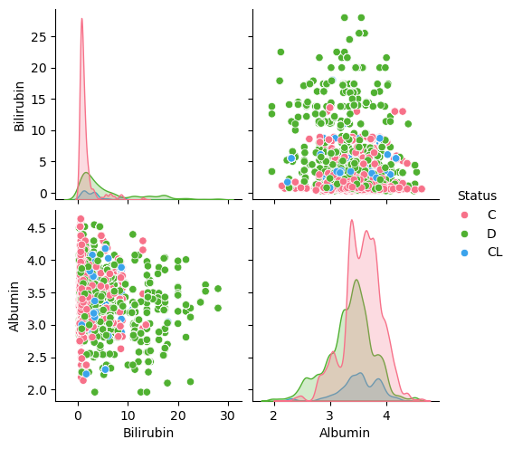

```python
sns.pairplot(df, vars=['Bilirubin', 'Albumin'], hue="Status", palette="husl")
plt.show()
```

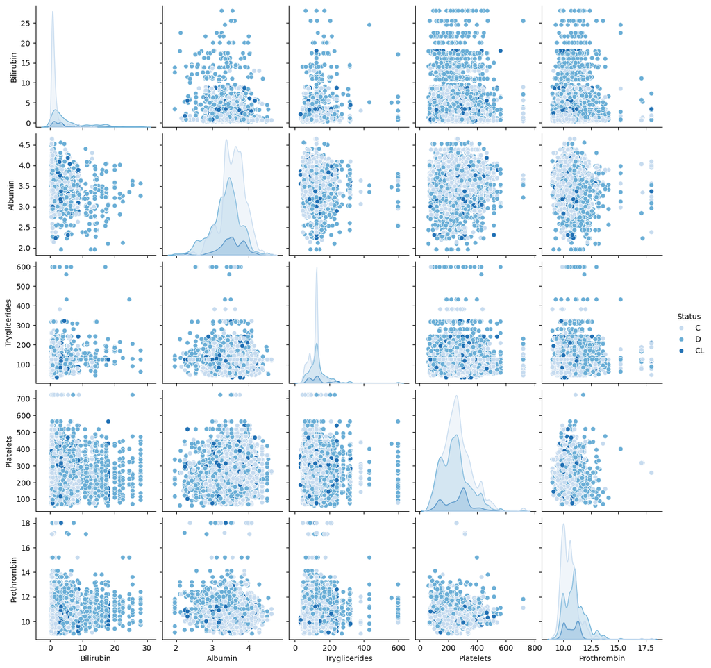

```python
sns.pairplot(df, vars=['Bilirubin', 'Albumin', 'Tryglicerides', 'Platelets', 'Prothrombin'],
             hue="Status", palette="Blues")
plt.show()
```

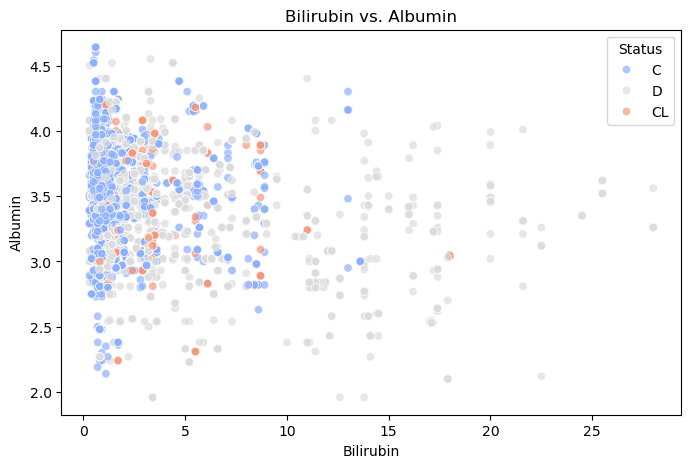

```python
plt.figure(figsize=(8, 5))
sns.scatterplot(x='Bilirubin', y='Albumin', data=df, hue='Status', palette="coolwarm", alpha=0.7)
plt.title("Bilirubin vs. Albumin")
plt.xlabel("Bilirubin")
plt.ylabel("Albumin")
plt.show()
```

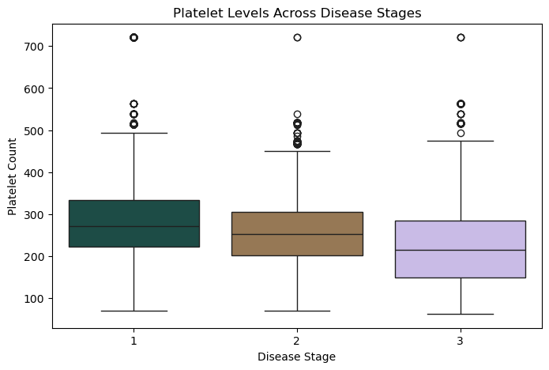

```python
plt.figure(figsize=(8, 5))
sns.boxplot(x='Stage', y='Platelets', data=df, palette="cubehelix")
plt.title("Platelet Levels Across Disease Stages")
plt.xlabel("Disease Stage")
plt.ylabel("Platelet Count")
plt.show()
```

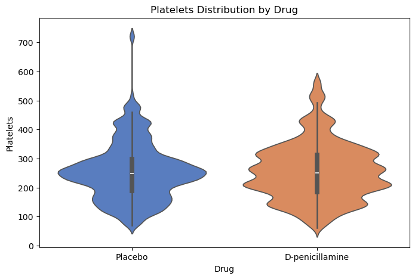

```python
plt.figure(figsize=(8, 5))
sns.violinplot(x='Drug', y='Platelets', data=df, palette="muted")
plt.title("Platelets Distribution by Drug")
plt.xlabel("Drug")
plt.ylabel("Platelets")
plt.show()
```

[figure not shown]

```python
plt.figure(figsize=(8, 5))
sns.barplot(x='Drug', y='Albumin', data=df, palette="cubehelix")
plt.title("Albumin Levels Across Disease Stages")
plt.xlabel("Disease Stage")
plt.ylabel("Albumin Count")
plt.show()
```

[figure not shown]

```python
plt.figure(figsize=(8, 5))
sns.barplot(x='Drug', y='Bilirubin', data=df, palette="cubehelix")
plt.title("Bilirubin Levels Across Disease Stages")
plt.xlabel("Disease Stage")
plt.ylabel("Bilirubin Count")
plt.show()
```

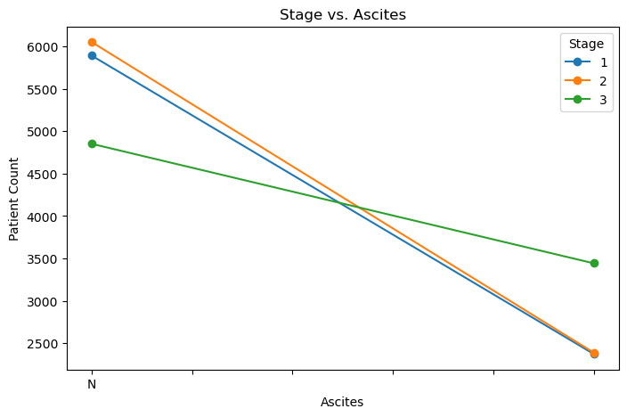

```python
plt.figure(figsize=(8, 5))
status_drug_counts = df.groupby(['Ascites', 'Stage']).size().unstack()
status_drug_counts.plot(kind="line", marker="o", figsize=(8, 5))
plt.title("Stage vs. Ascites")
plt.xlabel("Ascites")
plt.ylabel("Patient Count")
plt.legend(title="Stage")
plt.show()
```

[figure not shown]

```python
plt.figure(figsize=(8, 5))
status_drug_counts = df.groupby(['Ascites', 'Edema']).size().unstack()
status_drug_counts.plot(kind="line", marker="o", figsize=(8, 5))
plt.title("Stage vs Edema")
plt.xlabel("Edema")
plt.ylabel("Patient Count")
plt.legend(title="Stage")
plt.show()
```

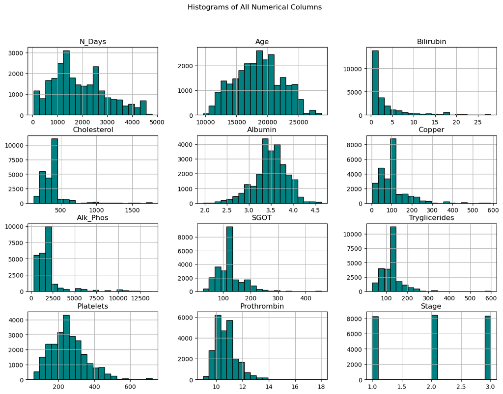

```python
df.hist(figsize=(14, 10), bins=20, color="teal", edgecolor="black")
plt.suptitle("Histograms of All Numerical Columns")
plt.show()
```

# DATA PREPROCESSING

## Feature Encoding in Machine Learning

#### Feature encoding is the process of converting categorical data into numerical form so that machine learning models can understand and process it. Since many models (like linear regression, SVM, and neural networks) work with numerical values, encoding is crucial when dealing with categorical variables.

```python
from sklearn.preprocessing import LabelEncoder

from sklearn.model_selection import train_test_split

from sklearn.tree import DecisionTreeClassifier
from sklearn.ensemble import RandomForestClassifier, GradientBoostingClassifier

from sklearn.metrics import accuracy_score, classification_report, confusion_matrix
```

```python
Cat_Col = []
Num_Col = []
```

```python
for col in df.columns:
    if df[col].dtype == 'object':
        Cat_Col.append(col)
    else:
        Num_Col.append(col)
```

```python
Cat_Col
```

```
['Status', 'Drug', 'Sex', 'Ascites', 'Hepatomegaly', 'Spiders', 'Edema']
```

```python
Num_Col
```

```
['N_Days',
 'Age',
 'Bilirubin',
 'Cholesterol',
 'Albumin',
 'Copper',
 'Alk_Phos',
 'SGOT',
 'Tryglicerides',
 'Platelets',
 'Prothrombin',
 'Stage']
```

### Label Encoding (LE)

#### Label Encoding is a technique used to convert categorical values into numerical values. It assigns a unique integer (0, 1, 2, …) to each category in a column.

#### Machine Learning Algorithms Need Numbers: Most models can’t work with text data directly. They require numerical inputs.

#### Simple & Efficient: It replaces categories with numbers efficiently, taking up less memory than one-hot encoding.

#### Useful for Ordered Data: If your categorical values have a meaningful order (e.g., "Low", "Medium", "High"), then label encoding makes sense.

```python
LE = LabelEncoder()
```

```python
LE = {}
```

```python
for col in Cat_Col:
    encoder = LabelEncoder()
    df[col] = encoder.fit_transform(df[col])
    LE[f"{col}_Encoder"] = encoder
    df[col].value_counts()
```

```python
LE
```

```
{'Status_Encoder': LabelEncoder(),
 'Drug_Encoder': LabelEncoder(),
 'Sex_Encoder': LabelEncoder(),
 'Ascites_Encoder': LabelEncoder(),
 'Hepatomegaly_Encoder': LabelEncoder(),
 'Spiders_Encoder': LabelEncoder(),
 'Edema_Encoder': LabelEncoder()}
```

```python
df.columns
```

```
Index(['N_Days', 'Status', 'Drug', 'Age', 'Sex', 'Ascites', 'Hepatomegaly',
       'Spiders', 'Edema', 'Bilirubin', 'Cholesterol', 'Albumin', 'Copper',
       'Alk_Phos', 'SGOT', 'Tryglicerides', 'Platelets', 'Prothrombin',
       'Stage'],
      dtype='object')
```

```python
df.info()
```

```
<class 'pandas.core.frame.DataFrame'>
RangeIndex: 25000 entries, 0 to 24999
Data columns (total 19 columns):
 #   Column         Non-Null Count  Dtype
---  ------         --------------  -----
 0   N_Days         25000 non-null  int64
 1   Status         25000 non-null  int64
 2   Drug           25000 non-null  int64
 3   Age            25000 non-null  int64
 4   Sex            25000 non-null  int64
 5   Ascites        25000 non-null  int64
 6   Hepatomegaly   25000 non-null  int64
 7   Spiders        25000 non-null  int64
 8   Edema          25000 non-null  int64
 9   Bilirubin      25000 non-null  float64
 10  Cholesterol    25000 non-null  float64
 11  Albumin        25000 non-null  float64
 12  Copper         25000 non-null  float64
 13  Alk_Phos       25000 non-null  float64
 14  SGOT           25000 non-null  float64
 15  Tryglicerides  25000 non-null  float64
 16  Platelets      25000 non-null  float64
 17  Prothrombin    25000 non-null  float64
 18  Stage          25000 non-null  int64
dtypes: float64(9), int64(10)
memory usage: 3.6 MB
```

```python
df.head()
```

|  | N_Days | Status | Drug | Age | Sex | Ascites | Hepatomegaly | Spiders | Edema | Bilirubin | Cholesterol | Albumin | Copper | Alk_Phos | SGOT | Tryglicerides | Platelets | Prothrombin | Stage |
| --- | --- | --- | --- | --- | --- | --- | --- | --- | --- | --- | --- | --- | --- | --- | --- | --- | --- | --- | --- |
| 0 | 2221 | 0 | 1 | 18499 | 0 | 0 | 1 | 0 | 0 | 0.5 | 149.0 | 4.04 | 227.0 | 598.0 | 52.70 | 57.0 | 256.0 | 9.9 | 1 |
| 1 | 1230 | 0 | 1 | 19724 | 1 | 1 | 0 | 1 | 0 | 0.5 | 219.0 | 3.93 | 22.0 | 663.0 | 45.00 | 75.0 | 220.0 | 10.8 | 2 |
| 2 | 4184 | 0 | 1 | 11839 | 0 | 0 | 0 | 0 | 0 | 0.5 | 320.0 | 3.54 | 51.0 | 1243.0 | 122.45 | 80.0 | 225.0 | 10.0 | 2 |
| 3 | 2090 | 2 | 1 | 16467 | 0 | 0 | 0 | 0 | 0 | 0.7 | 255.0 | 3.74 | 23.0 | 1024.0 | 77.50 | 58.0 | 151.0 | 10.2 | 2 |
| 4 | 2105 | 2 | 1 | 21699 | 0 | 0 | 1 | 0 | 0 | 1.9 | 486.0 | 3.54 | 74.0 | 1052.0 | 108.50 | 109.0 | 151.0 | 11.5 | 1 |

```python
df.describe()
```

|  | N_Days | Status | Drug | Age | Sex | Ascites | Hepatomegaly | Spiders | Edema | Bilirubin | Cholesterol | Albumin | Copper | Alk_Phos | SGOT | Tryglicerides | Platelets | Prothrombin | Stage |
| --- | --- | --- | --- | --- | --- | --- | --- | --- | --- | --- | --- | --- | --- | --- | --- | --- | --- | --- | --- |
| count | 25000.000000 | 25000.000000 | 25000.000000 | 25000.000000 | 25000.000000 | 25000.000000 | 25000.000000 | 25000.00000 | 25000.00000 | 25000.000000 | 25000.000000 | 25000.000000 | 25000.000000 | 25000.000000 | 25000.000000 | 25000.000000 | 25000.000000 | 25000.000000 | 25000.00000 |
| mean | 1887.117040 | 0.837600 | 0.633080 | 18495.877080 | 0.114520 | 0.328080 | 0.390280 | 0.45544 | 0.23448 | 3.402644 | 372.331471 | 3.486578 | 100.184663 | 1995.675597 | 123.166345 | 123.822548 | 256.007337 | 10.734549 | 2.00116 |
| std | 1091.690918 | 0.944744 | 0.481974 | 3737.596616 | 0.318448 | 0.469524 | 0.487823 | 0.49802 | 0.51582 | 4.707491 | 193.668452 | 0.380488 | 73.184840 | 1798.885660 | 47.747616 | 52.786350 | 98.679006 | 0.904436 | 0.81387 |
| min | 41.000000 | 0.000000 | 0.000000 | 9598.000000 | 0.000000 | 0.000000 | 0.000000 | 0.00000 | 0.00000 | 0.300000 | 120.000000 | 1.960000 | 4.000000 | 289.000000 | 26.350000 | 33.000000 | 62.000000 | 9.000000 | 1.00000 |
| 25% | 1080.000000 | 0.000000 | 0.000000 | 15694.000000 | 0.000000 | 0.000000 | 0.000000 | 0.00000 | 0.00000 | 0.800000 | 275.000000 | 3.290000 | 52.000000 | 1032.000000 | 92.000000 | 92.000000 | 189.000000 | 10.000000 | 1.00000 |
| 50% | 1680.000000 | 0.000000 | 1.000000 | 18499.000000 | 0.000000 | 0.000000 | 0.000000 | 0.00000 | 0.00000 | 1.300000 | 369.510563 | 3.510000 | 97.648387 | 1828.000000 | 122.556346 | 124.702128 | 251.000000 | 10.600000 | 2.00000 |
| 75% | 2576.000000 | 2.000000 | 1.000000 | 20955.000000 | 0.000000 | 1.000000 | 1.000000 | 1.00000 | 0.00000 | 3.400000 | 369.510563 | 3.750000 | 107.000000 | 1982.655769 | 134.850000 | 127.000000 | 311.000000 | 11.100000 | 3.00000 |
| max | 4795.000000 | 2.000000 | 1.000000 | 28650.000000 | 1.000000 | 1.000000 | 1.000000 | 1.00000 | 2.00000 | 28.000000 | 1775.000000 | 4.640000 | 588.000000 | 13862.400000 | 457.250000 | 598.000000 | 721.000000 | 18.000000 | 3.00000 |

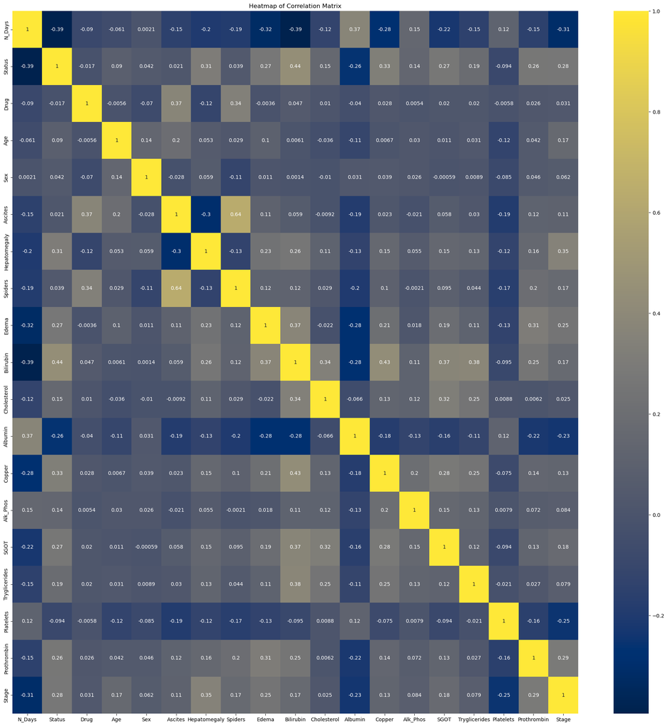

```python
plt.figure(figsize=(25,25))
correlation_matrix = df.corr()
sns.heatmap(correlation_matrix, annot=True, cmap='cividis')
plt.title('Heatmap of Correlation Matrix')
plt.show()
```

```python
print(df.dtypes)
```

```
N_Days             int64
Status             int64
Drug               int64
Age                int64
Sex                int64
Ascites            int64
Hepatomegaly       int64
Spiders            int64
Edema              int64
Bilirubin        float64
Cholesterol      float64
Albumin          float64
Copper           float64
Alk_Phos         float64
SGOT             float64
Tryglicerides    float64
Platelets        float64
Prothrombin      float64
Stage              int64
dtype: object
```

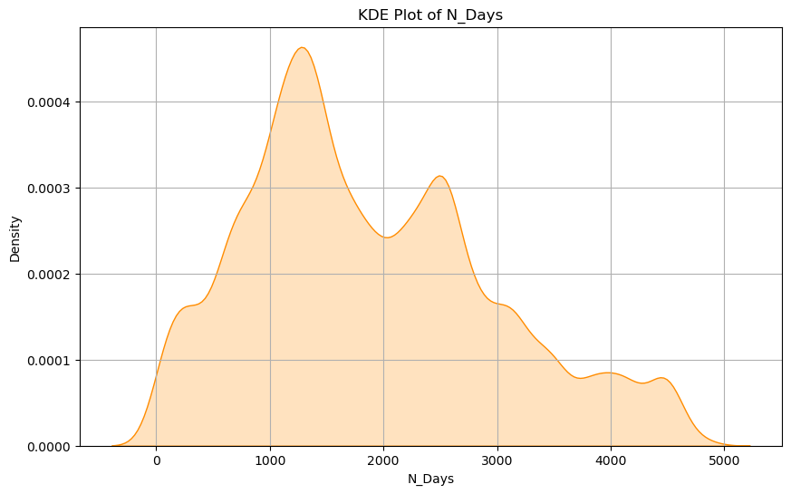

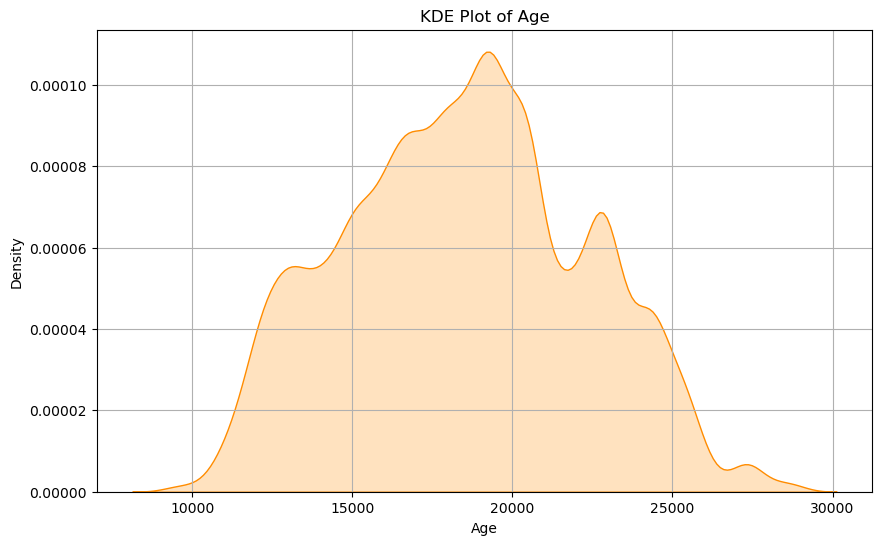

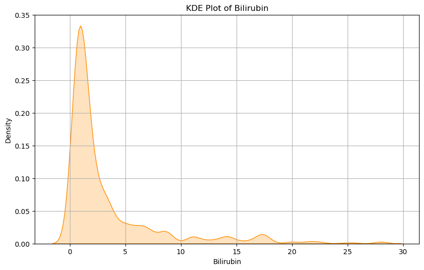

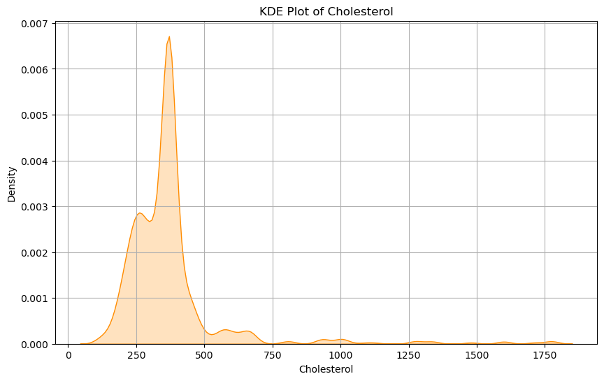

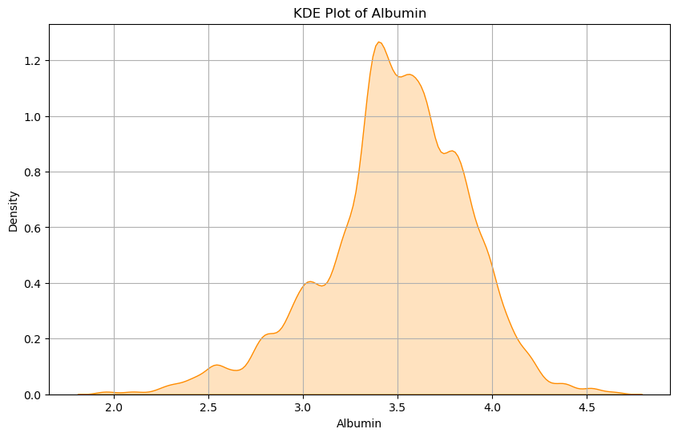

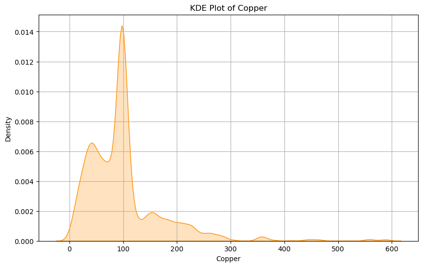

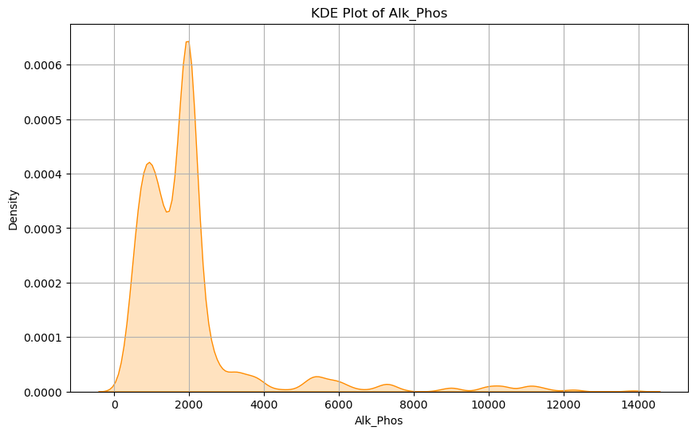

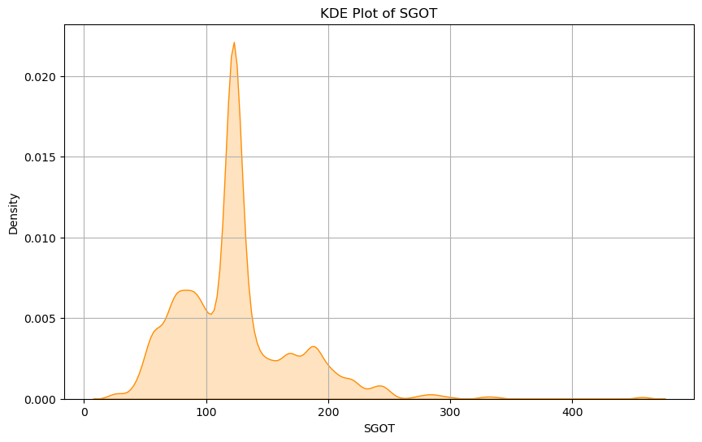

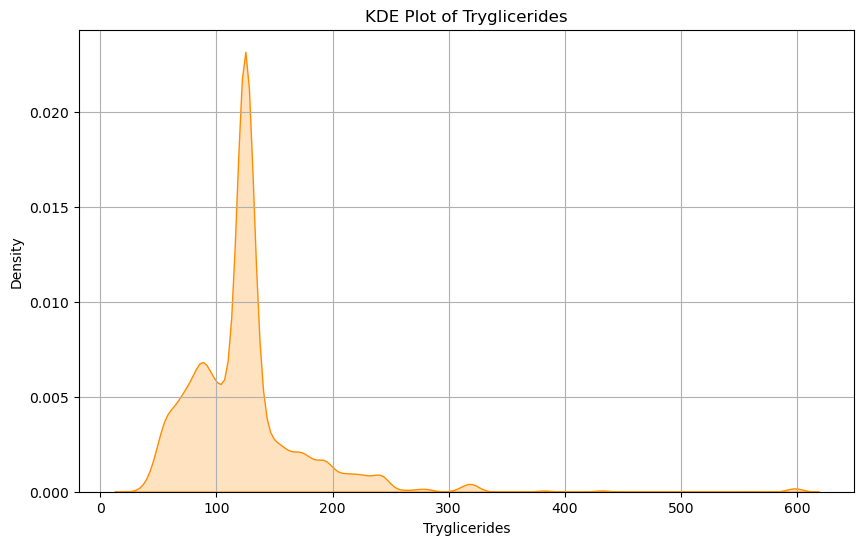

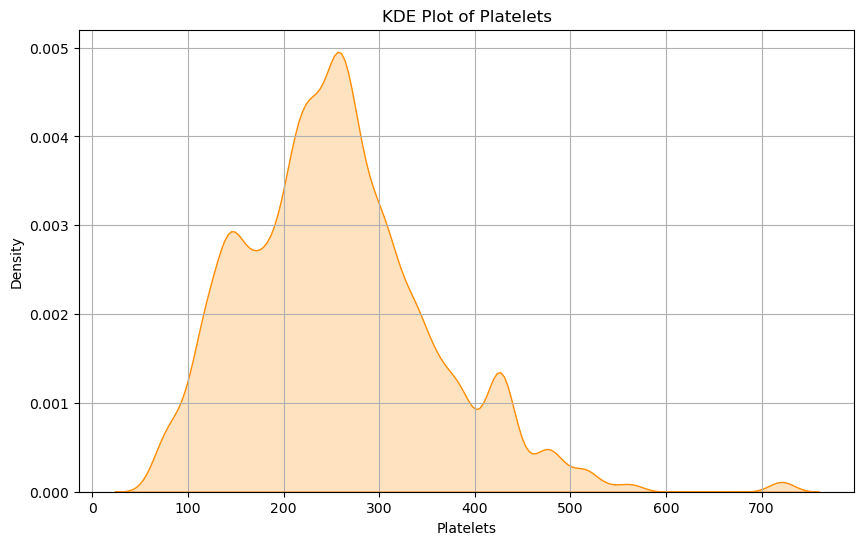

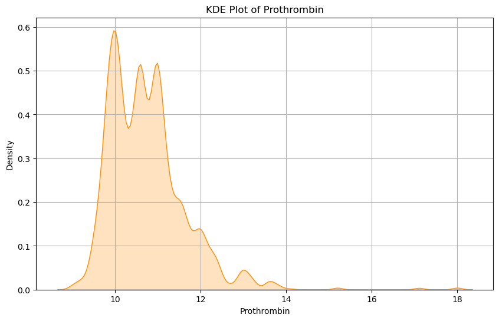

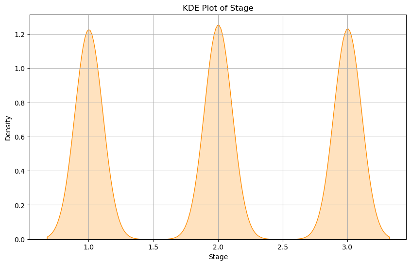

```python
for col in Num_Col:
    plt.figure(figsize=(10, 6))
    sns.kdeplot(data=df, x=col, fill=True, color='darkorange', bw_adjust=1)
    plt.title(f'KDE Plot of {col}')
    plt.xlabel(col)
    plt.ylabel('Density')
    plt.grid(True)
    plt.show()
```